# Suomi-datan kaivelua

## Johdanto

Valitaan tarkasteluun vain Suomi-aineisto.

Asetellaan vähän puuttuvia arvoja:

- Kysymyksissä merkitään “En osaa sanoa” puuttuvaksi
- Sukupuolimuuttujalle merkitään puuttuvaksi “Muu”
- Ikäryhmämuuttujalle merkitään puuttuvaksi “Don’t know”
- Koulutusmuuttujalle merkitään puuttuvaksi “Don’t know”
- Äänestyskysymyksessä merkitään puuttuviksi vaihtoehdot
  - “Ei äänioikeutta”
  - “En äänestänyt”
  - “En halua vastata”
  - “En osaa sanoa”
  - “Other”

Aloitetaan silmäilemällä kolmea kysymystä:

- Q4 Mitkä ovat mielestäsi median tehtäviä tiedon tuottamisessa ja ihmisten yhteiskunnallisen osallistumisen tukemisessa?
- Q5 Miten paljon seuraavilla henkilöillä ja tekijöillä on mielestäsi vaikutusvaltaa median toimintaan?
- Q6 Mistä yleisön luottamus journalistiseen mediaan mielestäsi rakentuu?

Kustakin tarkastellaa miten vastaukset ovat jakautuneet, sekä tarkastellaan sitä miten vastausten keskiarvot eroavat muutamien luokittelevien muuttujien suhteen: sukupuolen, ikäluokan, koulutustason sekä puoluekannan. Esitellään kussakin tapauksessa ensin kuvaaja, sitten taulukko. Taulukot ovat tässä vaiheessa valitettavasti hieman vaikeasti selattavia, mutta varsinkin taulujen koon kasvaessa niiden esittäminen nätisti käy työlääksi.

Tarkasteluun olisi mahdollista lisätä esimerkiksi erot vastausten jakautumisessa sukupolittain, mutta kun luokittelevien muuttujien mahdollisia kategorioita on joissain tapauksissa aika paljon, tästä tulee nopeasti vähän sekavaa. Pyydettäessä voin lisätä.

Huomaathan dokumenttia lukiessa, että painotettuja vastaajamääriä ei ole tässä vaiheessa pyöristetty kokonaisluvuiksi, mistä seuraa, etteivät prosenttiosuudet välttämättä summaudu sataan. Tämä näkyy mm. joissain kuvaajissa erikokoisina pylväinä.

## Q4 Mitkä ovat mielestäsi median tehtäviä tiedon tuottamisessa ja ihmisten yhteiskunnallisen osallistumisen tukemisessa?

### Kaikki vastaajat

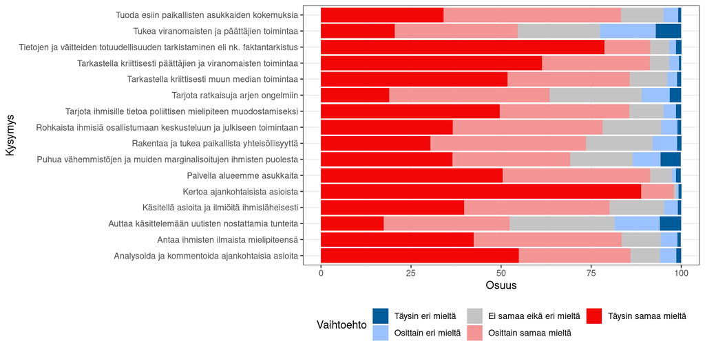

| Kysymys | Täysin eri mieltä | Osittain eri mieltä | Ei samaa eikä eri mieltä | Osittain samaa mieltä | Täysin samaa mieltä | Keskiarvo |
| --- | --- | --- | --- | --- | --- | --- |
| Palvella alueemme asukkaita | 1.4 | 1.1 | 6.0 | 41.0 | 50.4 | 4.378870 |
| Kertoa ajankohtaisista asioista | 0.8 | 0.7 | 0.7 | 9.0 | 88.9 | 4.843422 |
| Tuoda esiin paikallisten asukkaiden kokemuksia | 0.8 | 4.1 | 11.8 | 49.3 | 34.0 | 4.114869 |
| Rakentaa ja tukea paikallista yhteisöllisyyttä | 1.3 | 6.8 | 18.4 | 43.2 | 30.4 | 3.945356 |
| Rohkaista ihmisiä osallistumaan keskusteluun ja julkiseen toimintaan | 1.1 | 4.4 | 16.3 | 41.6 | 36.6 | 4.081716 |
| Tarjota ihmisille tietoa poliittisen mielipiteen muodostamiseksi | 1.5 | 3.4 | 9.5 | 36.0 | 49.6 | 4.286668 |
| Antaa ihmisten ilmaista mielipiteensä | 1.0 | 4.5 | 10.9 | 41.1 | 42.4 | 4.194170 |
| Puhua vähemmistöjen ja muiden marginalisoitujen ihmisten puolesta | 5.6 | 7.8 | 17.3 | 32.7 | 36.5 | 3.866278 |
| Käsitellä asioita ja ilmiöitä ihmisläheisesti | 0.9 | 3.8 | 15.2 | 40.4 | 39.7 | 4.140021 |
| Analysoida ja kommentoida ajankohtaisia asioita | 1.4 | 4.4 | 8.3 | 31.0 | 54.9 | 4.336093 |

[output cut: 6 more lines]

### Sukupuoli

Sitten katsotaan, miten keskiarvot eroavat sukupuolittain. Erot eivät näytä dramaattisilta, mutta selvimmät erot taidetaan nähdä vähemmistöjen puolesta puhumisen sekä tunteiden käsittelyn suhteen: molemmissa tapauksissa naiset pitävät tehtävää tärkeämpänä kuin miehet.

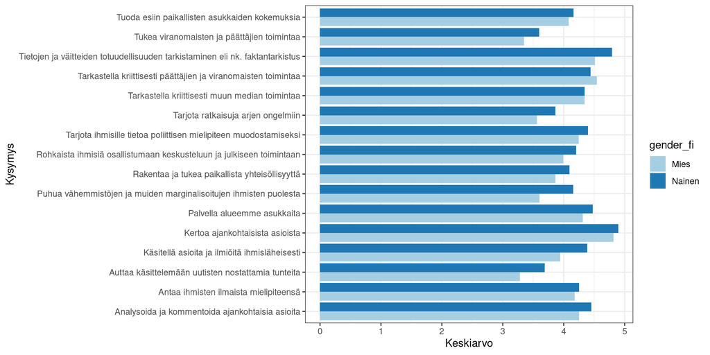

| Kysymys | gender_fi | Täysin eri mieltä | Osittain eri mieltä | Ei samaa eikä eri mieltä | Osittain samaa mieltä | Täysin samaa mieltä | Keskiarvo |
| --- | --- | --- | --- | --- | --- | --- | --- |
| Palvella alueemme asukkaita | Mies | 1.9 | 1.1 | 8.2 | 42.4 | 46.4 | 4.313176 |
| Palvella alueemme asukkaita | Nainen | 1.0 | 1.2 | 3.8 | 39.5 | 54.5 | 4.476714 |
| Kertoa ajankohtaisista asioista | Mies | 0.7 | 0.8 | 0.9 | 12.2 | 85.5 | 4.819201 |
| Kertoa ajankohtaisista asioista | Nainen | 1.0 | 0.6 | 0.5 | 5.8 | 92.2 | 4.895263 |
| Tuoda esiin paikallisten asukkaiden kokemuksia | Mies | 0.9 | 4.9 | 11.5 | 49.8 | 32.8 | 4.082656 |
| Tuoda esiin paikallisten asukkaiden kokemuksia | Nainen | 0.7 | 3.3 | 12.2 | 48.5 | 35.2 | 4.162790 |
| Rakentaa ja tukea paikallista yhteisöllisyyttä | Mies | 1.5 | 8.7 | 19.8 | 44.2 | 25.8 | 3.861356 |
| Rakentaa ja tukea paikallista yhteisöllisyyttä | Nainen | 1.1 | 4.8 | 16.9 | 42.1 | 35.1 | 4.092542 |
| Rohkaista ihmisiä osallistumaan keskusteluun ja julkiseen toimintaan | Mies | 1.2 | 5.4 | 19.9 | 41.1 | 32.4 | 3.993601 |
| Rohkaista ihmisiä osallistumaan keskusteluun ja julkiseen toimintaan | Nainen | 0.9 | 3.4 | 12.7 | 42.1 | 40.8 | 4.202639 |

[output cut: 22 more lines]

### Ikäryhmä

Sama ikäryhmittäin. En huomaa äkkiseltään dramaattisia eroja. Nuoret korostavat enemmän vähemmistöjen puolesta puhumista, vanhemmat viranomaisten ja päättäjien toiminnan tukemista.

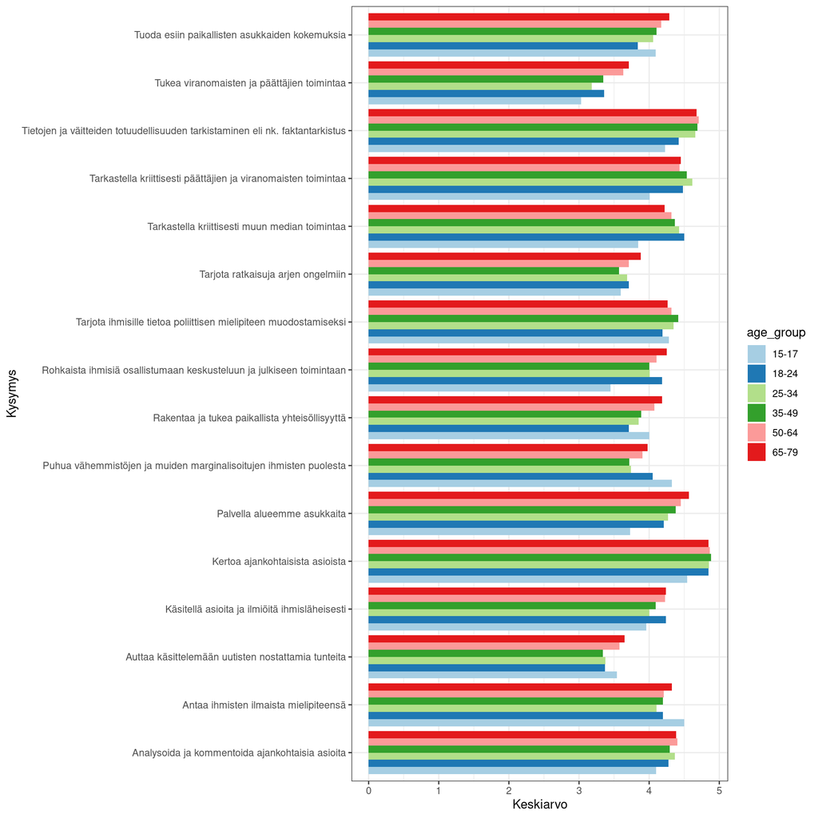

| Kysymys | age_group | Täysin eri mieltä | Osittain eri mieltä | Ei samaa eikä eri mieltä | Osittain samaa mieltä | Täysin samaa mieltä | Keskiarvo |
| --- | --- | --- | --- | --- | --- | --- | --- |
| Palvella alueemme asukkaita | 15-17 | 15.0 | 0.0 | 19.2 | 65.8 | 0.0 | 3.725494 |
| Palvella alueemme asukkaita | 18-24 | 0.0 | 3.1 | 8.1 | 52.9 | 35.8 | 4.209961 |
| Palvella alueemme asukkaita | 25-34 | 2.2 | 1.2 | 4.5 | 49.7 | 42.3 | 4.270342 |
| Palvella alueemme asukkaita | 35-49 | 0.4 | 1.3 | 7.3 | 43.1 | 47.9 | 4.380057 |
| Palvella alueemme asukkaita | 50-64 | 0.7 | 0.8 | 6.2 | 36.5 | 55.7 | 4.451394 |
| Palvella alueemme asukkaita | 65-79 | 2.5 | 0.2 | 3.4 | 28.7 | 65.1 | 4.568886 |
| Kertoa ajankohtaisista asioista | 15-17 | 0.0 | 21.5 | 0.0 | 12.7 | 65.8 | 4.540651 |
| Kertoa ajankohtaisista asioista | 18-24 | 0.0 | 1.4 | 1.2 | 5.9 | 91.5 | 4.848290 |
| Kertoa ajankohtaisista asioista | 25-34 | 0.0 | 0.0 | 2.1 | 10.1 | 87.7 | 4.849645 |
| Kertoa ajankohtaisista asioista | 35-49 | 0.7 | 0.0 | 0.7 | 8.8 | 89.8 | 4.881297 |

[output cut: 86 more lines]

### Koulutusaste

Koulutusasteen mukaan. Keskiarvojen tasolla en näe dramaattisia eroja.

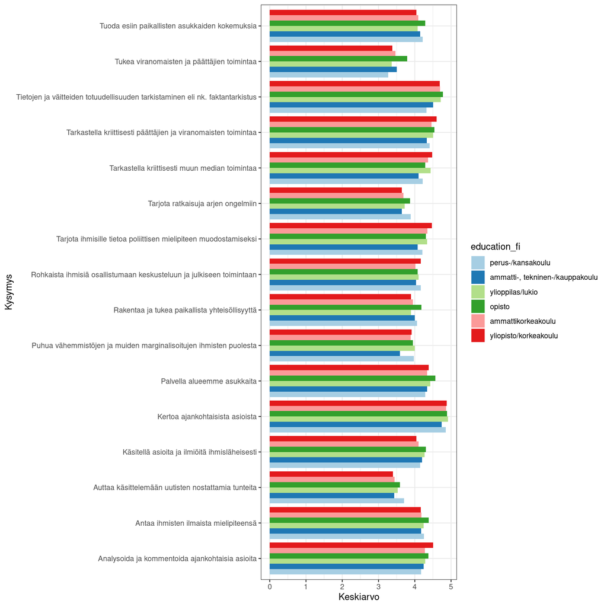

| Kysymys | education_fi | Täysin eri mieltä | Osittain eri mieltä | Ei samaa eikä eri mieltä | Osittain samaa mieltä | Täysin samaa mieltä | Keskiarvo |
| --- | --- | --- | --- | --- | --- | --- | --- |
| Palvella alueemme asukkaita | perus-/kansakoulu | 0.0 | 3.4 | 8.7 | 43.4 | 44.5 | 4.287178 |
| Palvella alueemme asukkaita | ammatti-, tekninen-/kauppakoulu | 1.6 | 0.3 | 6.7 | 44.1 | 47.3 | 4.342198 |
| Palvella alueemme asukkaita | ylioppilas/lukio | 1.7 | 0.0 | 8.3 | 42.9 | 47.1 | 4.423124 |
| Palvella alueemme asukkaita | opisto | 0.9 | 1.2 | 2.5 | 32.7 | 62.6 | 4.564449 |
| Palvella alueemme asukkaita | ammattikorkeakoulu | 3.2 | 1.0 | 6.4 | 39.7 | 49.6 | 4.336535 |
| Palvella alueemme asukkaita | yliopisto/korkeakoulu | 0.5 | 1.8 | 5.3 | 42.1 | 50.3 | 4.387999 |
| Kertoa ajankohtaisista asioista | perus-/kansakoulu | 0.0 | 1.7 | 0.0 | 11.3 | 87.0 | 4.853579 |
| Kertoa ajankohtaisista asioista | ammatti-, tekninen-/kauppakoulu | 1.8 | 0.8 | 0.7 | 14.4 | 82.4 | 4.741388 |
| Kertoa ajankohtaisista asioista | ylioppilas/lukio | 0.0 | 1.7 | 1.0 | 6.0 | 91.3 | 4.916111 |
| Kertoa ajankohtaisista asioista | opisto | 1.5 | 0.0 | 0.6 | 5.7 | 92.2 | 4.891945 |

[output cut: 86 more lines]

### Asuinpaikka

Tässä varmaan odotettaisiin suurten paikkakuntien erottuvan muista. Ei äkkiseltään erityisemmin näytä siltä?

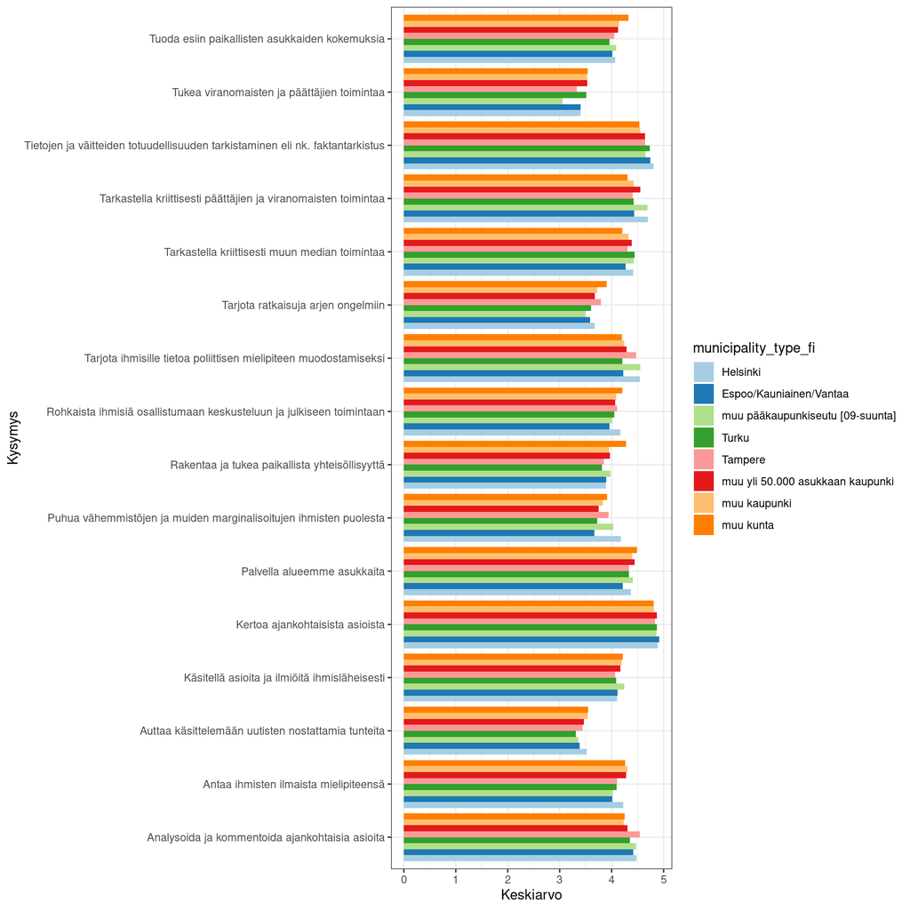

| Kysymys | municipality_type_fi | Täysin eri mieltä | Osittain eri mieltä | Ei samaa eikä eri mieltä | Osittain samaa mieltä | Täysin samaa mieltä | Keskiarvo |
| --- | --- | --- | --- | --- | --- | --- | --- |
| Palvella alueemme asukkaita | Helsinki | 0.4 | 2.0 | 7.1 | 45.3 | 45.2 | 4.367739 |
| Palvella alueemme asukkaita | Espoo/Kauniainen/Vantaa | 0.6 | 2.3 | 7.5 | 50.1 | 39.4 | 4.217942 |
| Palvella alueemme asukkaita | muu pääkaupunkiseutu [09-suunta] | 0.0 | 2.2 | 3.8 | 46.9 | 47.2 | 4.404382 |
| Palvella alueemme asukkaita | Turku | 2.3 | 0.0 | 2.6 | 52.8 | 42.4 | 4.333032 |
| Palvella alueemme asukkaita | Tampere | 0.0 | 3.3 | 10.1 | 33.7 | 53.0 | 4.332089 |
| Palvella alueemme asukkaita | muu yli 50.000 asukkaan kaupunki | 2.0 | 1.0 | 5.7 | 39.1 | 52.2 | 4.440705 |
| Palvella alueemme asukkaita | muu kaupunki | 2.6 | 0.0 | 5.0 | 38.9 | 53.5 | 4.393942 |
| Palvella alueemme asukkaita | muu kunta | 1.3 | 0.0 | 5.4 | 34.2 | 59.1 | 4.490835 |
| Kertoa ajankohtaisista asioista | Helsinki | 0.4 | 0.0 | 0.5 | 7.4 | 91.8 | 4.887655 |
| Kertoa ajankohtaisista asioista | Espoo/Kauniainen/Vantaa | 0.6 | 0.0 | 0.9 | 5.2 | 93.3 | 4.919276 |

[output cut: 118 more lines]

### Puoluekanta

Ja puoluekannan mukaan:

Tässä alkaa olla jo tavaraa sen verran paljon, että tulkitseminen menee pikkaisen hankalaksi. Voidaan kuitenkin huomata, että tavanomaisimmat epäillyt erottuvat jonkin verran: mm. perussuomalaisten kannattajat pitävät vähemmistöjen puolesta puhumista huomattavasti vähemmän tärkeänä kuin muut, ja näyttävät olevan jonkin verran vähemmän samaa mieltä myös muutamista muista väitteistä. Perussuomalaisten kannattajat ovat mm. vähemmän samaa mieltä kuin muut väitteestä, että median tulisi tarjota tietoa oman poliittisen mielipiteen muodostamisen tueksi, tai analysoida ja kommentoida ajankohtaisia asioita. Voisi kenties tulkita, että nämä ovat asioita joissa perussuomalaiset eivät luota mediaan.

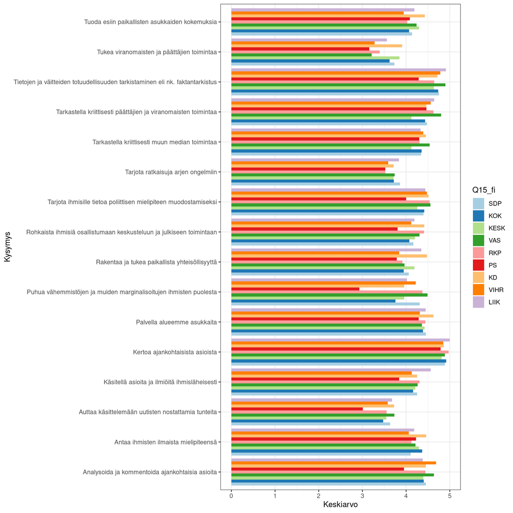

| Kysymys | Q15_fi | Täysin eri mieltä | Osittain eri mieltä | Ei samaa eikä eri mieltä | Osittain samaa mieltä | Täysin samaa mieltä | Keskiarvo |
| --- | --- | --- | --- | --- | --- | --- | --- |
| Palvella alueemme asukkaita | SDP | 2.8 | 1.0 | 5.0 | 34.5 | 56.7 | 4.452158 |
| Palvella alueemme asukkaita | KOK | 1.4 | 0.5 | 7.1 | 42.8 | 48.2 | 4.383526 |
| Palvella alueemme asukkaita | KESK | 2.2 | 0.0 | 5.3 | 37.8 | 54.6 | 4.419716 |
| Palvella alueemme asukkaita | VAS | 0.0 | 1.0 | 5.8 | 49.4 | 43.8 | 4.362488 |
| Palvella alueemme asukkaita | RKP | 0.0 | 0.0 | 2.5 | 50.2 | 47.3 | 4.439740 |
| Palvella alueemme asukkaita | PS | 1.4 | 1.8 | 9.1 | 36.5 | 51.2 | 4.290989 |
| Palvella alueemme asukkaita | KD | 0.0 | 3.0 | 0.0 | 36.6 | 60.4 | 4.625707 |
| Palvella alueemme asukkaita | VIHR | 0.0 | 3.1 | 6.1 | 45.9 | 44.8 | 4.309999 |
| Palvella alueemme asukkaita | LIIK | 0.0 | 0.0 | 6.9 | 44.0 | 49.2 | 4.445021 |
| Kertoa ajankohtaisista asioista | SDP | 1.9 | 0.4 | 0.0 | 6.0 | 91.7 | 4.885879 |

[output cut: 134 more lines]

## Q5 Miten paljon seuraavilla henkilöillä ja tekijöillä on mielestäsi vaikutusvaltaa median toimintaan?

### Kaikki vastaajat

Näistä vaihtoehdoista joukosta erottuu ainakin “yleisötutkimukset ja -data”; rehellisesti sanottuna epäilen, että kysymys on vain vähän epämääräinen ja suurin osa vastaajista on sitten mutulla heittänyt vastaukseksi “jonkin verran”. Johtoportaalla, omistajilla ja bisneslogiikalla arvellaan olevan aika paljon vaikutusvaltaa, toimittajien henkilökohtaisilla näkemyksillä lähes yhtä paljon. “Vähän vaikutusvaltaa”- ja “Ei lainkaan vaikutusvaltaa”-vaihtoehdot ovat vastaajien joukossa aika epäsuosittuja kautta linjan.

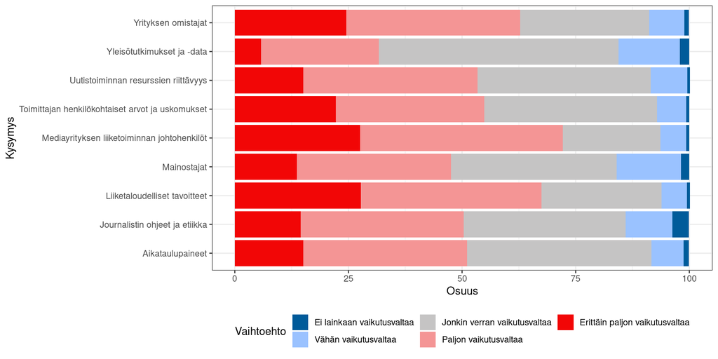

### Sukupuoli

Tarkastellaan sitten taas keskiarvoja ryhmittäin. Ensin sukupuoli. Ihan hirveän suuria eroja ei näy: miehet mahdollisesti korostavat toimittajien henkilökohtaisia näkemyksiä, naiset bisnekseen liittyviä tekijöitä ja journalistin ohjeita.

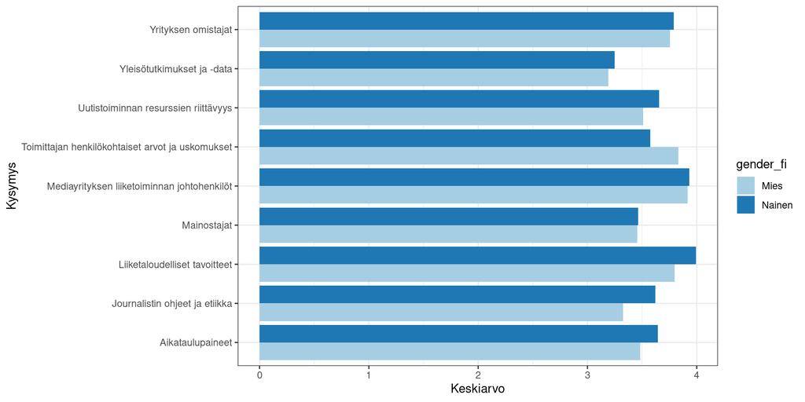

| Kysymys | gender_fi | Ei lainkaan vaikutusvaltaa | Vähän vaikutusvaltaa | Jonkin verran vaikutusvaltaa | Paljon vaikutusvaltaa | Erittäin paljon vaikutusvaltaa | Keskiarvo |
| --- | --- | --- | --- | --- | --- | --- | --- |
| Toimittajan henkilökohtaiset arvot ja uskomukset | Mies | 0.8 | 4.3 | 33.9 | 33.1 | 28.0 | 3.832695 |
| Toimittajan henkilökohtaiset arvot ja uskomukset | Nainen | 0.7 | 8.6 | 42.2 | 32.0 | 16.5 | 3.573433 |
| Mediayrityksen liiketoiminnan johtohenkilöt | Mies | 1.1 | 6.4 | 21.1 | 42.7 | 28.7 | 3.915858 |
| Mediayrityksen liiketoiminnan johtohenkilöt | Nainen | 0.2 | 5.1 | 21.7 | 46.4 | 26.6 | 3.932504 |
| Yrityksen omistajat | Mies | 1.1 | 9.1 | 28.3 | 36.2 | 25.3 | 3.755900 |
| Yrityksen omistajat | Nainen | 0.9 | 6.3 | 28.5 | 40.4 | 23.8 | 3.788822 |
| Mainostajat | Mies | 1.6 | 15.1 | 35.1 | 35.1 | 13.1 | 3.456183 |
| Mainostajat | Nainen | 2.0 | 13.3 | 37.6 | 32.9 | 14.3 | 3.463368 |
| Liiketaloudelliset tavoitteet | Mies | 1.2 | 7.7 | 27.5 | 38.5 | 25.1 | 3.797593 |
| Liiketaloudelliset tavoitteet | Nainen | 0.0 | 3.4 | 25.1 | 41.3 | 30.2 | 3.993656 |

[output cut: 8 more lines]

### Ikäryhmät

Ikäryhmien tarkemman tulkinnan jätän jälleen innokkaammille. Nuorilla hieman enemmän kriittisyyttä bisneslogiikkaa kohtaan?

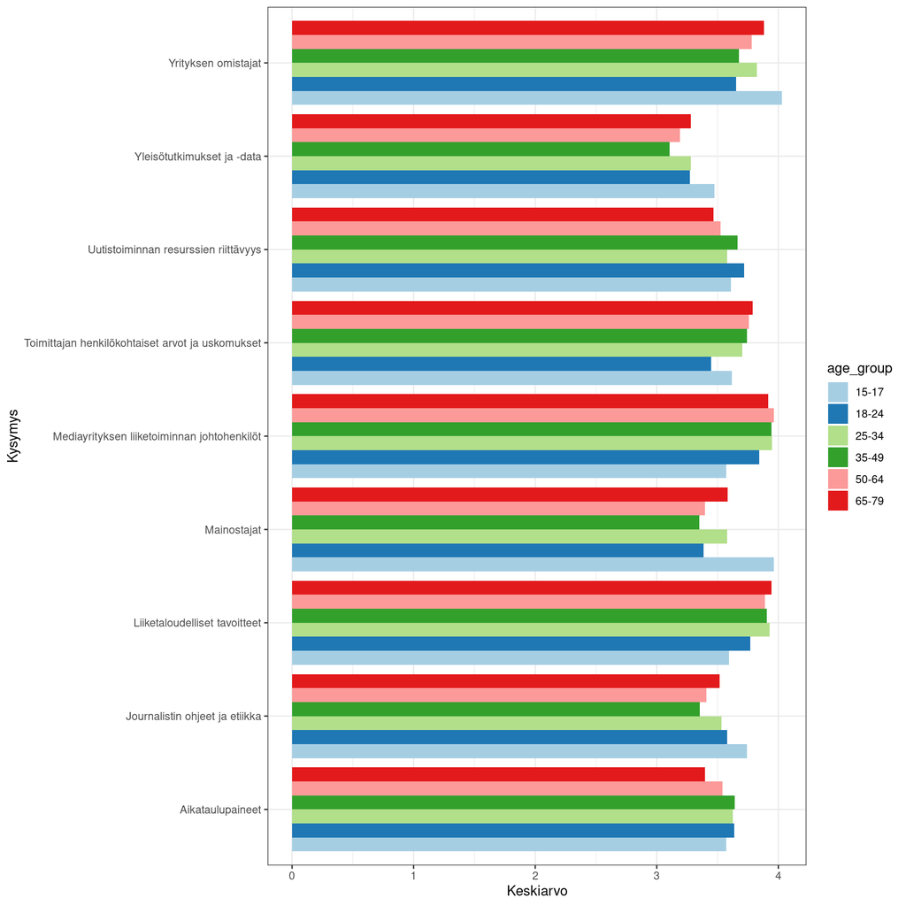

| Kysymys | age_group | Ei lainkaan vaikutusvaltaa | Vähän vaikutusvaltaa | Jonkin verran vaikutusvaltaa | Paljon vaikutusvaltaa | Erittäin paljon vaikutusvaltaa | Keskiarvo |
| --- | --- | --- | --- | --- | --- | --- | --- |
| Toimittajan henkilökohtaiset arvot ja uskomukset | 15-17 | 0.0 | 12.2 | 30.6 | 44.4 | 12.7 | 3.616784 |
| Toimittajan henkilökohtaiset arvot ja uskomukset | 18-24 | 0.0 | 8.1 | 55.2 | 24.6 | 12.1 | 3.446975 |
| Toimittajan henkilökohtaiset arvot ja uskomukset | 25-34 | 1.2 | 6.0 | 40.2 | 28.7 | 24.0 | 3.702381 |
| Toimittajan henkilökohtaiset arvot ja uskomukset | 35-49 | 1.0 | 7.0 | 36.9 | 29.5 | 25.5 | 3.741947 |
| Toimittajan henkilökohtaiset arvot ja uskomukset | 50-64 | 0.5 | 5.9 | 33.8 | 36.6 | 23.2 | 3.758057 |
| Toimittajan henkilökohtaiset arvot ja uskomukset | 65-79 | 0.9 | 5.1 | 32.7 | 38.5 | 22.9 | 3.790103 |
| Mediayrityksen liiketoiminnan johtohenkilöt | 15-17 | 6.5 | 0.0 | 20.8 | 72.8 | 0.0 | 3.570418 |
| Mediayrityksen liiketoiminnan johtohenkilöt | 18-24 | 0.0 | 10.1 | 23.4 | 42.8 | 23.7 | 3.841939 |
| Mediayrityksen liiketoiminnan johtohenkilöt | 25-34 | 0.8 | 7.9 | 22.5 | 35.6 | 33.2 | 3.946480 |
| Mediayrityksen liiketoiminnan johtohenkilöt | 35-49 | 0.3 | 4.5 | 22.2 | 47.0 | 26.0 | 3.943652 |

[output cut: 44 more lines]

### Koulutusaste

Koulutusasteen mukaan. Tämäkin vaatisi tarkempaa syynäämistä, mutta keskiarvojen tasolla en jälleen näe ihan dramaattisia eroja.

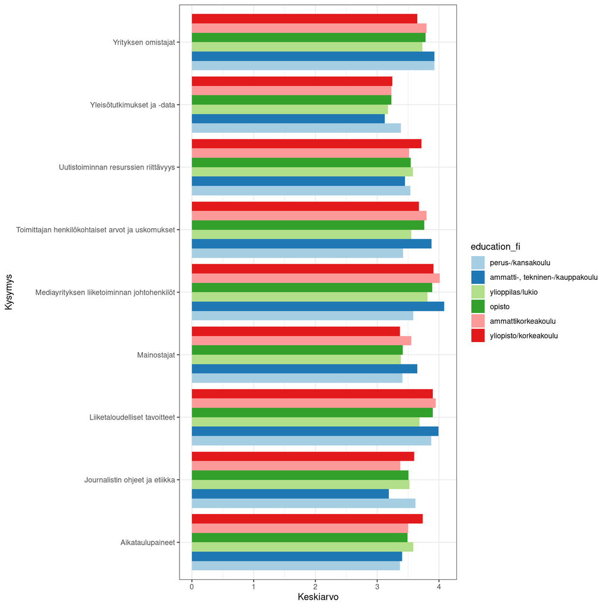

| Kysymys | education_fi | Ei lainkaan vaikutusvaltaa | Vähän vaikutusvaltaa | Jonkin verran vaikutusvaltaa | Paljon vaikutusvaltaa | Erittäin paljon vaikutusvaltaa | Keskiarvo |
| --- | --- | --- | --- | --- | --- | --- | --- |
| Toimittajan henkilökohtaiset arvot ja uskomukset | perus-/kansakoulu | 1.4 | 12.3 | 45.7 | 23.0 | 17.6 | 3.420901 |
| Toimittajan henkilökohtaiset arvot ja uskomukset | ammatti-, tekninen-/kauppakoulu | 1.2 | 7.2 | 25.7 | 32.8 | 33.1 | 3.878332 |
| Toimittajan henkilökohtaiset arvot ja uskomukset | ylioppilas/lukio | 1.3 | 10.3 | 39.9 | 36.5 | 12.0 | 3.553872 |
| Toimittajan henkilökohtaiset arvot ja uskomukset | opisto | 0.5 | 4.0 | 38.2 | 35.0 | 22.4 | 3.764155 |
| Toimittajan henkilökohtaiset arvot ja uskomukset | ammattikorkeakoulu | 1.1 | 4.7 | 36.4 | 30.4 | 27.4 | 3.798585 |
| Toimittajan henkilökohtaiset arvot ja uskomukset | yliopisto/korkeakoulu | 0.0 | 4.7 | 44.0 | 33.1 | 18.1 | 3.672948 |
| Mediayrityksen liiketoiminnan johtohenkilöt | perus-/kansakoulu | 1.8 | 7.6 | 29.1 | 46.5 | 15.1 | 3.584556 |
| Mediayrityksen liiketoiminnan johtohenkilöt | ammatti-, tekninen-/kauppakoulu | 0.8 | 5.1 | 13.6 | 38.6 | 41.8 | 4.086415 |
| Mediayrityksen liiketoiminnan johtohenkilöt | ylioppilas/lukio | 0.8 | 4.8 | 29.2 | 45.9 | 19.3 | 3.814183 |
| Mediayrityksen liiketoiminnan johtohenkilöt | opisto | 0.6 | 3.4 | 21.8 | 50.5 | 23.6 | 3.890716 |

[output cut: 44 more lines]

### Asuinpaikka

En näe selviä eroja.

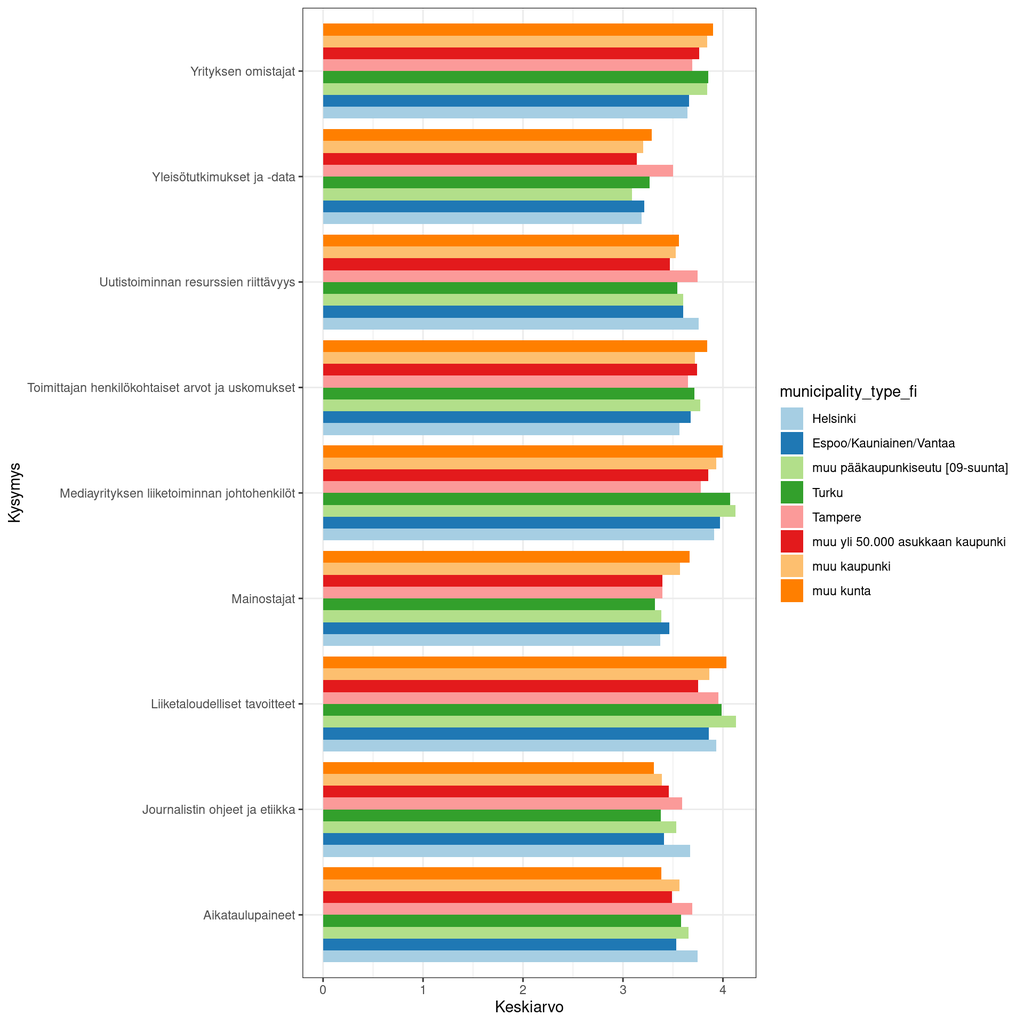

| Kysymys | municipality_type_fi | Ei lainkaan vaikutusvaltaa | Vähän vaikutusvaltaa | Jonkin verran vaikutusvaltaa | Paljon vaikutusvaltaa | Erittäin paljon vaikutusvaltaa | Keskiarvo |
| --- | --- | --- | --- | --- | --- | --- | --- |
| Toimittajan henkilökohtaiset arvot ja uskomukset | Helsinki | 0.0 | 4.4 | 52.2 | 27.9 | 15.6 | 3.564280 |
| Toimittajan henkilökohtaiset arvot ja uskomukset | Espoo/Kauniainen/Vantaa | 1.3 | 5.9 | 38.8 | 27.1 | 26.9 | 3.678678 |
| Toimittajan henkilökohtaiset arvot ja uskomukset | muu pääkaupunkiseutu [09-suunta] | 0.0 | 6.3 | 39.5 | 29.4 | 24.7 | 3.775121 |
| Toimittajan henkilökohtaiset arvot ja uskomukset | Turku | 0.0 | 7.4 | 43.7 | 33.8 | 15.2 | 3.714075 |
| Toimittajan henkilökohtaiset arvot ja uskomukset | Tampere | 0.0 | 6.0 | 35.8 | 36.9 | 21.2 | 3.648123 |
| Toimittajan henkilökohtaiset arvot ja uskomukset | muu yli 50.000 asukkaan kaupunki | 1.2 | 5.4 | 35.9 | 34.3 | 23.2 | 3.742160 |
| Toimittajan henkilökohtaiset arvot ja uskomukset | muu kaupunki | 0.9 | 10.1 | 31.7 | 37.7 | 19.6 | 3.717802 |
| Toimittajan henkilökohtaiset arvot ja uskomukset | muu kunta | 1.0 | 6.2 | 31.6 | 30.3 | 31.0 | 3.842664 |
| Mediayrityksen liiketoiminnan johtohenkilöt | Helsinki | 0.9 | 5.8 | 23.1 | 43.7 | 26.5 | 3.914307 |
| Mediayrityksen liiketoiminnan johtohenkilöt | Espoo/Kauniainen/Vantaa | 0.0 | 8.1 | 19.5 | 42.3 | 30.1 | 3.971667 |

[output cut: 62 more lines]

### Puoluekanta

Ja puoluekannan mukaan. Tässä erottuvat Liike Nytin kannattajat, joita on kuitenkin aineistossa hyvin vähän. Muuten joitain kiinnostavia eroja pointattavaksi on: perussuomalaiset pitävät selkeästi muita merkittävämpinä toimittajien henkilökohtaisia näkemyksiä ja journalistin ohjeita vähemmän merkittävinä, vasemmistoliittolaiset liiketaloudellisia tavoitteita.

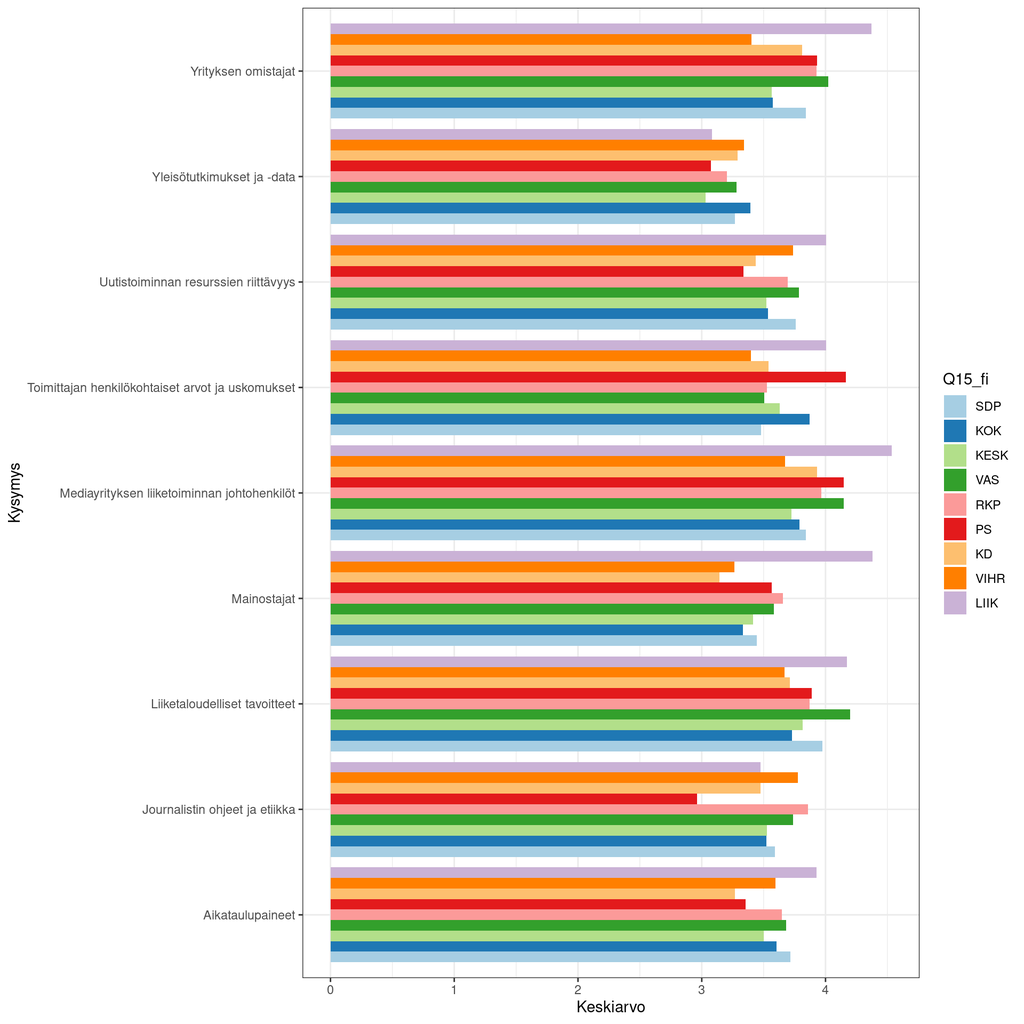

| Kysymys | Q15_fi | Ei lainkaan vaikutusvaltaa | Vähän vaikutusvaltaa | Jonkin verran vaikutusvaltaa | Paljon vaikutusvaltaa | Erittäin paljon vaikutusvaltaa | Keskiarvo |
| --- | --- | --- | --- | --- | --- | --- | --- |
| Toimittajan henkilökohtaiset arvot ja uskomukset | SDP | 1.1 | 9.5 | 45.8 | 29.6 | 14.1 | 3.481221 |
| Toimittajan henkilökohtaiset arvot ja uskomukset | KOK | 0.4 | 5.3 | 32.1 | 39.1 | 23.1 | 3.873437 |
| Toimittajan henkilökohtaiset arvot ja uskomukset | KESK | 0.0 | 7.4 | 35.3 | 35.1 | 22.2 | 3.631870 |
| Toimittajan henkilökohtaiset arvot ja uskomukset | VAS | 0.0 | 5.1 | 47.6 | 40.2 | 7.1 | 3.505224 |
| Toimittajan henkilökohtaiset arvot ja uskomukset | RKP | 0.0 | 3.4 | 64.2 | 17.3 | 15.1 | 3.527342 |
| Toimittajan henkilökohtaiset arvot ja uskomukset | PS | 0.8 | 5.2 | 20.2 | 29.1 | 44.7 | 4.164511 |
| Toimittajan henkilökohtaiset arvot ja uskomukset | KD | 0.0 | 8.1 | 37.4 | 38.6 | 15.9 | 3.541207 |
| Toimittajan henkilökohtaiset arvot ja uskomukset | VIHR | 1.4 | 2.3 | 60.0 | 26.8 | 9.5 | 3.397662 |
| Toimittajan henkilökohtaiset arvot ja uskomukset | LIIK | 0.0 | 18.4 | 14.9 | 26.2 | 40.5 | 4.004843 |
| Mediayrityksen liiketoiminnan johtohenkilöt | SDP | 1.2 | 4.1 | 24.2 | 48.9 | 21.6 | 3.841284 |

[output cut: 71 more lines]

## Q6 Mistä yleisön luottamus journalistiseen mediaan mielestäsi rakentuu?

### Kaikki vastaajat

Lopuksi vielä median luottamuksen rakentumiseen liittyvät tekijät. Tässä kysymyksessä alakysymysten välillä nähdään jo selkeämpiä eroja. Tietojen paikkansapitävyys on (ilahduttavasti) erittäin tärkeä noin 80 prosentille vastaajista. Tasapuolisuuden ja käytäntöjen läpinäkvyyyden merkityksestä ollaan myös laajasti samaa mieltä. Toimittajan arvot ja kommentit sekä median maine merkitsevät vähemmän (näissä voisi olla kiinnostavia eroja mm. puoluekannan suhteen).

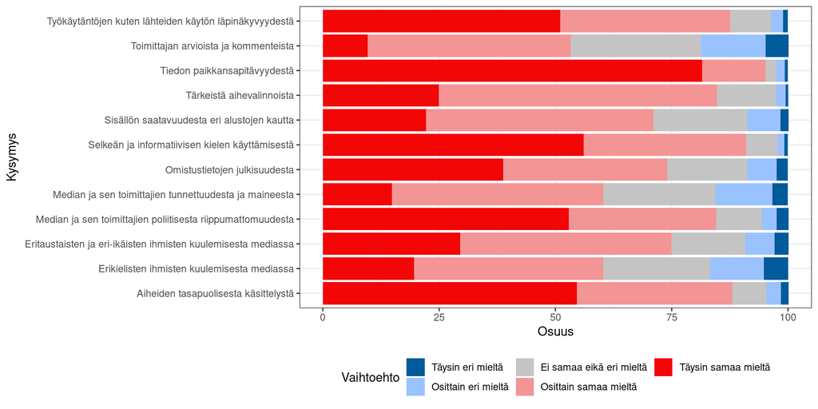

### Sukupuoli

Sitten tutkitaan taas sukupuolieroja. Keskiarvojen tasolla suuria eroja ei näy: merkittävin ero näyttää liittyvän erikielisten ihmisen kuulemisen merkitykseen, mikä on linjassa sen kanssa että miehet aiemmin pitivät myös vähemmistöjen puolesta puhumista vähemmän tärkeänä.

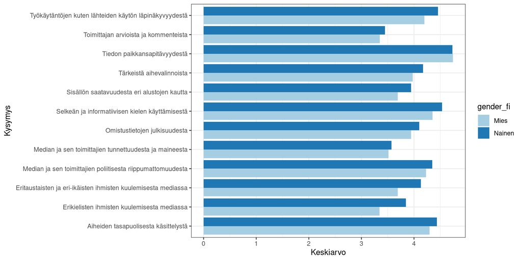

| Kysymys | gender_fi | Täysin eri mieltä | Osittain eri mieltä | Ei samaa eikä eri mieltä | Osittain samaa mieltä | Täysin samaa mieltä | Keskiarvo |
| --- | --- | --- | --- | --- | --- | --- | --- |
| Tärkeistä aihevalinnoista | Mies | 0.8 | 2.5 | 15.1 | 61.7 | 19.9 | 3.974343 |
| Tärkeistä aihevalinnoista | Nainen | 0.3 | 1.6 | 10.3 | 57.9 | 29.9 | 4.172296 |
| Tiedon paikkansapitävyydestä | Mies | 0.0 | 2.2 | 2.0 | 15.0 | 80.8 | 4.741910 |
| Tiedon paikkansapitävyydestä | Nainen | 1.2 | 1.7 | 2.5 | 12.6 | 82.1 | 4.729457 |
| Sisällön saatavuudesta eri alustojen kautta | Mies | 2.1 | 9.3 | 21.4 | 50.7 | 16.4 | 3.690332 |
| Sisällön saatavuudesta eri alustojen kautta | Nainen | 1.3 | 5.0 | 18.7 | 46.9 | 28.2 | 3.943442 |
| Toimittajan arvioista ja kommenteista | Mies | 5.9 | 14.8 | 27.2 | 43.1 | 8.9 | 3.351754 |
| Toimittajan arvioista ja kommenteista | Nainen | 3.8 | 12.9 | 28.9 | 44.1 | 10.3 | 3.450089 |
| Selkeän ja informatiivisen kielen käyttämisestä | Mies | 0.3 | 1.2 | 9.0 | 41.9 | 47.5 | 4.353443 |
| Selkeän ja informatiivisen kielen käyttämisestä | Nainen | 1.2 | 1.9 | 4.2 | 27.8 | 64.9 | 4.533286 |

[output cut: 14 more lines]

### Ikäryhmä

Ikäryhmittäin. Tästä pistää silmään lähinnä se, että nuoret mahdollisesti painottavat vähemmistöryhmien representoimista muita enemmän, samoin omistustietojen julkisuutta.

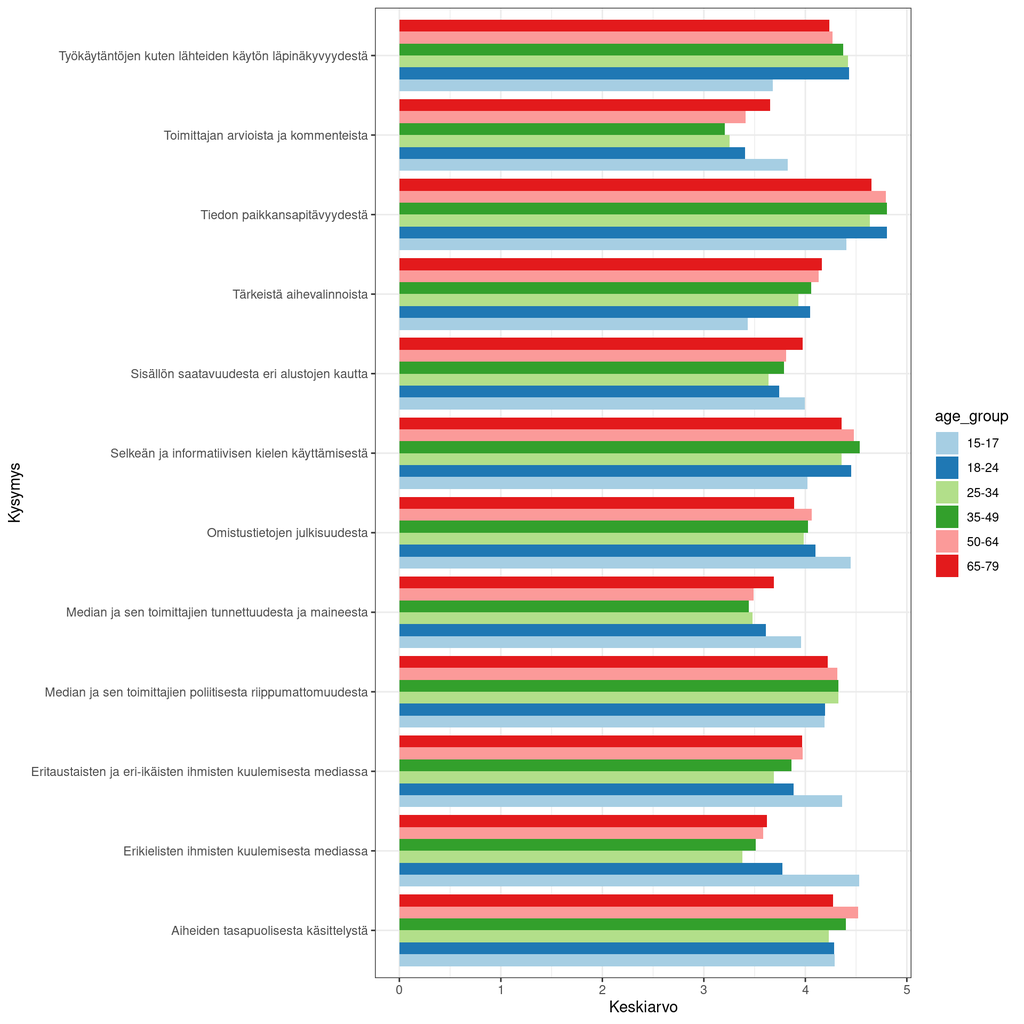

| Kysymys | age_group | Täysin eri mieltä | Osittain eri mieltä | Ei samaa eikä eri mieltä | Osittain samaa mieltä | Täysin samaa mieltä | Keskiarvo |
| --- | --- | --- | --- | --- | --- | --- | --- |
| Tärkeistä aihevalinnoista | 15-17 | 0.0 | 6.5 | 36.9 | 56.7 | 0.0 | 3.432627 |
| Tärkeistä aihevalinnoista | 18-24 | 0.0 | 2.2 | 8.2 | 73.3 | 16.3 | 4.048102 |
| Tärkeistä aihevalinnoista | 25-34 | 0.0 | 4.0 | 15.9 | 56.2 | 23.9 | 3.931788 |
| Tärkeistä aihevalinnoista | 35-49 | 1.4 | 1.4 | 10.5 | 63.3 | 23.5 | 4.058028 |
| Tärkeistä aihevalinnoista | 50-64 | 0.3 | 2.0 | 11.7 | 57.4 | 28.6 | 4.133350 |
| Tärkeistä aihevalinnoista | 65-79 | 0.7 | 1.1 | 14.5 | 53.8 | 30.0 | 4.162001 |
| Tiedon paikkansapitävyydestä | 15-17 | 0.0 | 0.0 | 9.1 | 34.2 | 56.7 | 4.402559 |
| Tiedon paikkansapitävyydestä | 18-24 | 0.8 | 0.0 | 0.0 | 14.8 | 84.4 | 4.803687 |
| Tiedon paikkansapitävyydestä | 25-34 | 1.2 | 3.3 | 3.3 | 13.3 | 79.0 | 4.635999 |
| Tiedon paikkansapitävyydestä | 35-49 | 0.7 | 1.7 | 0.9 | 10.2 | 86.5 | 4.804992 |

[output cut: 62 more lines]

### Koulutusaste

Koulutusaste ei taaskaan näytä hirveän merkittävältä.

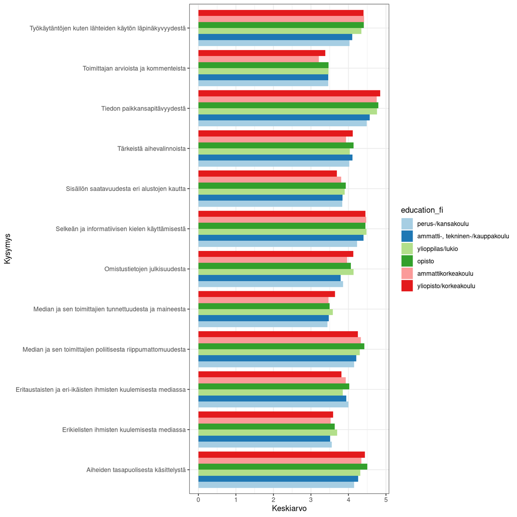

| Kysymys | education_fi | Täysin eri mieltä | Osittain eri mieltä | Ei samaa eikä eri mieltä | Osittain samaa mieltä | Täysin samaa mieltä | Keskiarvo |
| --- | --- | --- | --- | --- | --- | --- | --- |
| Tärkeistä aihevalinnoista | perus-/kansakoulu | 0.0 | 3.0 | 13.7 | 65.0 | 18.3 | 4.019979 |
| Tärkeistä aihevalinnoista | ammatti-, tekninen-/kauppakoulu | 0.4 | 2.4 | 14.7 | 56.6 | 25.9 | 4.104746 |
| Tärkeistä aihevalinnoista | ylioppilas/lukio | 0.0 | 2.8 | 12.8 | 60.1 | 24.3 | 4.035809 |
| Tärkeistä aihevalinnoista | opisto | 1.7 | 1.6 | 11.3 | 53.4 | 32.0 | 4.137764 |
| Tärkeistä aihevalinnoista | ammattikorkeakoulu | 0.0 | 0.4 | 18.7 | 63.0 | 17.9 | 3.936920 |
| Tärkeistä aihevalinnoista | yliopisto/korkeakoulu | 0.9 | 2.5 | 8.0 | 61.3 | 27.2 | 4.117519 |
| Tiedon paikkansapitävyydestä | perus-/kansakoulu | 0.0 | 3.7 | 5.2 | 24.4 | 66.7 | 4.487477 |
| Tiedon paikkansapitävyydestä | ammatti-, tekninen-/kauppakoulu | 0.5 | 3.6 | 5.3 | 18.0 | 72.5 | 4.563239 |
| Tiedon paikkansapitävyydestä | ylioppilas/lukio | 1.2 | 0.8 | 1.5 | 15.5 | 80.9 | 4.757792 |
| Tiedon paikkansapitävyydestä | opisto | 0.4 | 2.1 | 2.0 | 9.1 | 86.4 | 4.796449 |

[output cut: 62 more lines]

### Asuinpaikka

En näe selviä eroja tässäkään.

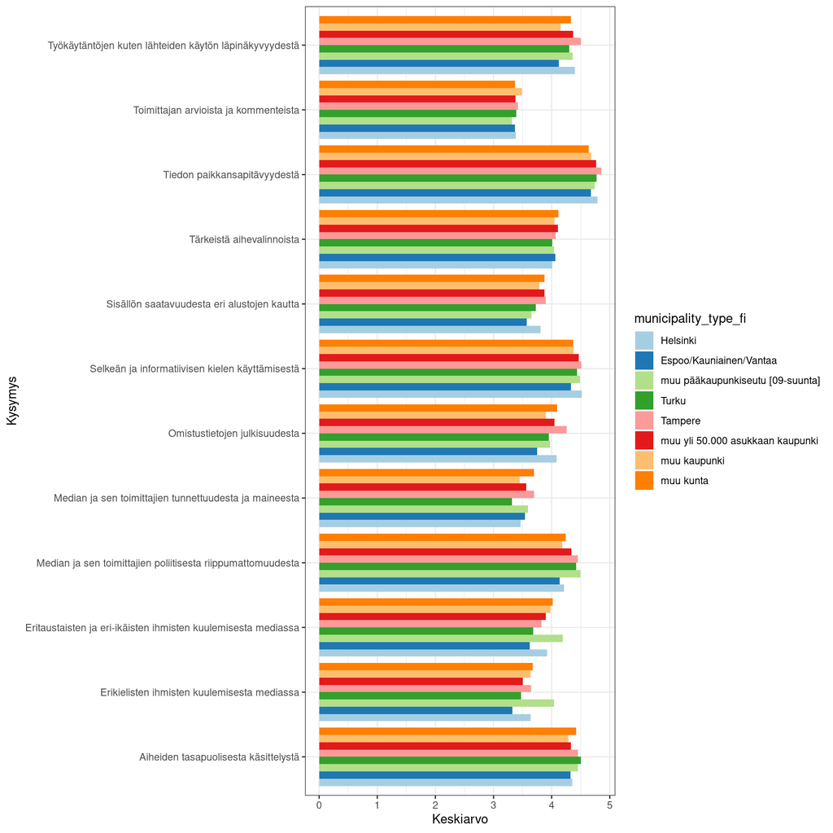

| Kysymys | municipality_type_fi | Täysin eri mieltä | Osittain eri mieltä | Ei samaa eikä eri mieltä | Osittain samaa mieltä | Täysin samaa mieltä | Keskiarvo |
| --- | --- | --- | --- | --- | --- | --- | --- |
| Tärkeistä aihevalinnoista | Helsinki | 1.9 | 3.2 | 9.4 | 63.8 | 21.6 | 4.007892 |
| Tärkeistä aihevalinnoista | Espoo/Kauniainen/Vantaa | 0.9 | 2.7 | 11.0 | 55.6 | 29.8 | 4.062912 |
| Tärkeistä aihevalinnoista | muu pääkaupunkiseutu [09-suunta] | 0.0 | 5.6 | 7.5 | 65.0 | 21.9 | 4.041833 |
| Tärkeistä aihevalinnoista | Turku | 0.0 | 2.2 | 14.7 | 66.4 | 16.6 | 4.012466 |
| Tärkeistä aihevalinnoista | Tampere | 0.0 | 2.3 | 13.5 | 57.0 | 27.2 | 4.074165 |
| Tärkeistä aihevalinnoista | muu yli 50.000 asukkaan kaupunki | 0.0 | 0.9 | 13.1 | 60.8 | 25.1 | 4.106891 |
| Tärkeistä aihevalinnoista | muu kaupunki | 0.9 | 1.6 | 14.9 | 59.1 | 23.5 | 4.051073 |
| Tärkeistä aihevalinnoista | muu kunta | 0.0 | 2.1 | 14.0 | 53.9 | 30.0 | 4.116112 |
| Tiedon paikkansapitävyydestä | Helsinki | 1.0 | 2.7 | 0.3 | 8.8 | 87.2 | 4.788074 |
| Tiedon paikkansapitävyydestä | Espoo/Kauniainen/Vantaa | 1.8 | 3.6 | 2.1 | 12.7 | 79.8 | 4.676052 |

[output cut: 86 more lines]

### Puoluekanta

Perussuomalaisille vähemmistöjen esittäminen merkitsee vähemmän kuin muille, vasemmistoliittolaisille kenties hieman enemmän. Muuten erot ovat aika hienovaraisia.

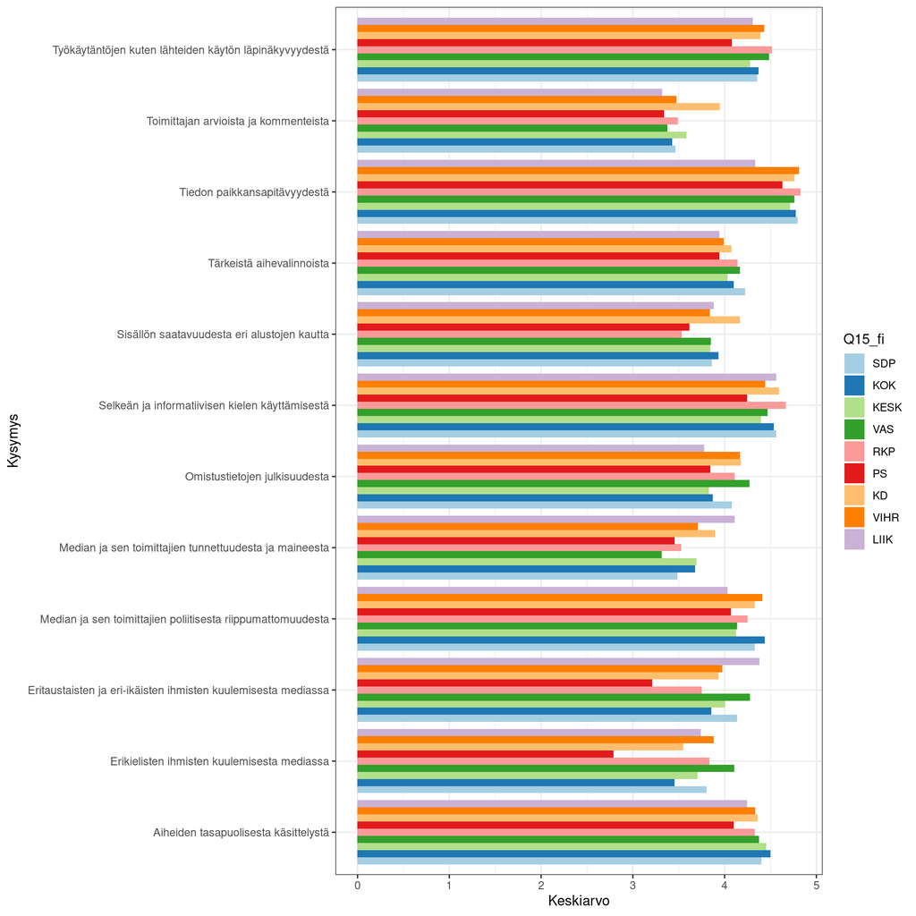

| Kysymys | Q15_fi | Täysin eri mieltä | Osittain eri mieltä | Ei samaa eikä eri mieltä | Osittain samaa mieltä | Täysin samaa mieltä | Keskiarvo |
| --- | --- | --- | --- | --- | --- | --- | --- |
| Tärkeistä aihevalinnoista | SDP | 0.0 | 0.6 | 8.3 | 61.3 | 29.8 | 4.225679 |
| Tärkeistä aihevalinnoista | KOK | 0.5 | 0.3 | 10.1 | 68.1 | 20.9 | 4.099692 |
| Tärkeistä aihevalinnoista | KESK | 0.0 | 1.1 | 15.1 | 64.1 | 19.8 | 4.033068 |
| Tärkeistä aihevalinnoista | VAS | 0.9 | 1.6 | 9.9 | 57.1 | 30.6 | 4.169015 |
| Tärkeistä aihevalinnoista | RKP | 0.0 | 6.8 | 5.6 | 50.2 | 37.4 | 4.140409 |
| Tärkeistä aihevalinnoista | PS | 1.3 | 2.9 | 19.2 | 53.8 | 22.7 | 3.945296 |
| Tärkeistä aihevalinnoista | KD | 3.0 | 0.0 | 5.9 | 68.0 | 23.1 | 4.071684 |
| Tärkeistä aihevalinnoista | VIHR | 0.0 | 4.7 | 11.5 | 58.4 | 25.3 | 3.991494 |
| Tärkeistä aihevalinnoista | LIIK | 0.0 | 0.0 | 13.0 | 69.0 | 17.9 | 3.942376 |
| Tiedon paikkansapitävyydestä | SDP | 0.4 | 1.7 | 2.5 | 11.9 | 83.5 | 4.794622 |

[output cut: 98 more lines]